# machineLearningTitanic

## Explore Data

```python
print('Number of Pregnant Women', df_data_1.count())
```

```
Number of Pregnant Women 189
```

```python
#Number of women who had low birth and those who did not
df_data_1.groupby('LOW').count().show()
```

```
+---+-----+
|LOW|count|
+---+-----+
|  0|  130|
|  1|   59|
+---+-----+
```

```
+--------+---+---+
|RACE_LOW|  0|  1|
+--------+---+---+
|       2| 15| 11|
|       1| 73| 23|
|       3| 42| 25|
+--------+---+---+
```

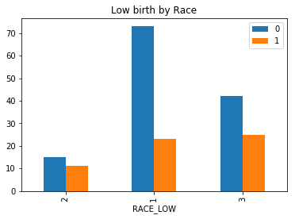

```python
#Number of women who had lowbirth and those who had lowbirth by Race
import matplotlib.pyplot as plt
%matplotlib inline
df_data_1.crosstab('RACE', 'LOW').show()
df=df_data_1.crosstab('RACE', 'LOW').toPandas()
df.plot.bar(x="RACE_LOW", legend=True , title="Low birth by Race")
```

```
+---------+---+---+
|SMOKE_LOW|  0|  1|
+---------+---+---+
|        1| 44| 30|
|        0| 86| 29|
+---------+---+---+
```

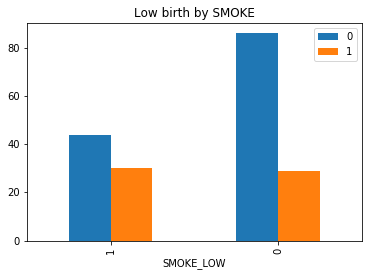

```python
#Number of women who had lowbirth by SMOKE
df_data_1.crosstab('SMOKE', 'LOW').show()
df=df_data_1.crosstab('SMOKE', 'LOW').toPandas()
df.plot.bar(x="SMOKE_LOW", legend=True , title="Low birth by SMOKE")
```

```
+-------+---+---+
|AGE_LOW|  0|  1|
+-------+---+---+
|     45|  1|  0|
|     34|  0|  1|
|     19| 13|  3|
|     23|  8|  5|
|     15|  1|  2|
|     33|  3|  0|
|     22| 11|  2|
|     26|  4|  4|
|     24|  8|  5|
|     35|  2|  0|
|     16|  6|  1|
|     21|  7|  5|
|     32|  5|  1|
|     36|  2|  0|
|     17|  7|  5|
|     25|  9|  6|
|     14|  1|  2|
|     31|  4|  1|
|     20| 10|  8|
|     27|  1|  2|
+-------+---+---+
only showing top 20 rows
```

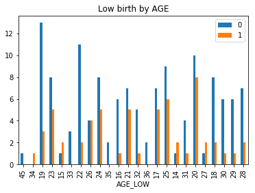

```python
#Number of women who had lowbirth by AGE
df_data_1.crosstab('AGE', 'LOW').show()
df=df_data_1.crosstab('AGE', 'LOW').toPandas()
df.plot.bar(x="AGE_LOW", legend=True , title="Low birth by AGE")
```

```
+-------+---+---+
|PTL_LOW|  0|  1|
+-------+---+---+
|      2|  3|  2|
|      1|  8| 16|
|      0|118| 41|
|      3|  1|  0|
+-------+---+---+
```

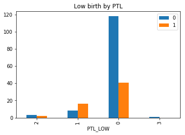

```python
#Number of women who had lowbirth by PTL
df_data_1.crosstab('PTL', 'LOW').show()
df=df_data_1.crosstab('PTL', 'LOW').toPandas()
df.plot.bar(x="PTL_LOW", legend=True , title="Low birth by PTL")
```

```
+------+---+---+
|HT_LOW|  0|  1|
+------+---+---+
|     1|  5|  7|
|     0|125| 52|
+------+---+---+
```

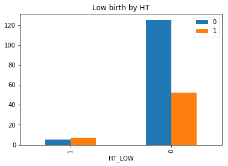

```python
#Number of women who had lowbirth by HT
df_data_1.crosstab('HT', 'LOW').show()
df=df_data_1.crosstab('HT', 'LOW').toPandas()
df.plot.bar(x="HT_LOW", legend=True , title="Low birth by HT")
```

```
+---------+---+---+
|SMOKE_LOW|  0|  1|
+---------+---+---+
|        1| 44| 30|
|        0| 86| 29|
+---------+---+---+
```

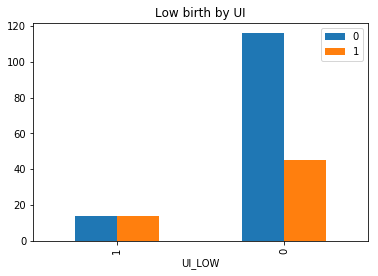

```python
#Number of women who had lowbirth by UI
df_data_1.crosstab('SMOKE', 'LOW').show()
df=df_data_1.crosstab('UI', 'LOW').toPandas()
df.plot.bar(x="UI_LOW", legend=True , title="Low birth by UI")
```

```python
#Number of women who had lowbirth by FTV
df_data_1.crosstab('FTV', 'LOW').show()
df=df_data_1.crosstab('SMOKE', 'LOW').toPandas()
```

```
+-------+---+---+
|FTV_LOW|  0|  1|
+-------+---+---+
|      4|  3|  1|
|      6|  1|  0|
|      1| 36| 11|
|      0| 64| 36|
|      2| 23|  7|
|      3|  3|  4|
+-------+---+---+
```

```python
# Average age by LOW outcome
# Convert Age data type from string to numeric.
pdf=df_data_1.toPandas()
pdf["AGE"]=pd.to_numeric(pdf.AGE)

df=sqlContext.createDataFrame(pdf)

PAge=df.groupby(['LOW'])\
.agg({"AGE": "AVG"}).toPandas()
PAge
```

|  | LOW | avg(AGE) |
| --- | --- | --- |
| 0 | 0 | 23.661538 |
| 1 | 1 | 22.305085 |

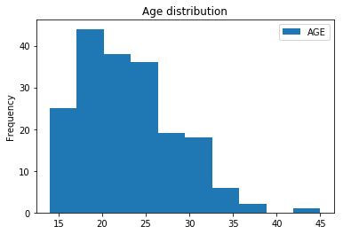

```python
#Age distribution for all pregnant women
pdf.plot.hist("AGE", title="Age distribution")
```

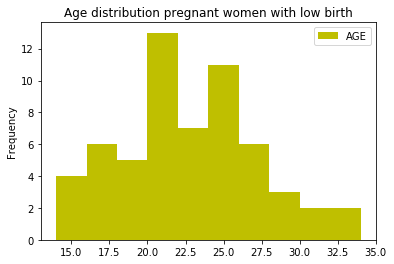

```python
# Age distribution for low birth pregnant women
df_low=df.select('AGE', 'LOW').filter(df['LOW']=='1')
pdf_low=df_low.toPandas()
pdf_low.plot.hist("AGE",  color='y',title="Age distribution pregnant women with low birth")
```

## Parse Data

Now let's load the data into a `Spark RDD` and output the number of rows and first 5 rows. Each project you create has a bucket in your object storage. You may get the bucket name from the project Settings page. Replace the string `BUCKET` to the bucket name

```python
data = sc.textFile(cos.url('lowbwt.csv', 'assignment2a-donotdelete-pr-6ug4ln0pkt5np1'))
print ("Total records in the data set:", data.count())
print ("The first 5 rows")
data.take(5)
```

```
Total records in the data set: 190
The first 5 rows
```

```
['ID,LOW,AGE,RACE,SMOKE,PTL,HT,UI,FTV',
 '85,0,19,2,0,0,0,1,0',
 '86,0,33,3,0,0,0,0,3',
 '87,0,20,1,1,0,0,0,1',
 '88,0,21,1,1,0,0,1,2']
```

Create DataFrame from RDD

```python
#Load the data into a ataframe, parse it using the function above
documents = data.filter(lambda s: "Name" not in s).map(parseDocument)
LowData = documents.toDF() # ToDataFrame
print ("Number of records: " + str(LowData.count()))
print ( "First 5 records: ")
LowData.take(5)
```

```
Number of records: 190
First 5 records:
```

```
[Row(PersonID='ID', PersonInfo='AGE RACE SMOKE PTL UI FTV', label=1.0),
 Row(PersonID='85', PersonInfo='19 2 0 0 1 0', label=0.0),
 Row(PersonID='86', PersonInfo='33 3 0 0 0 3', label=0.0),
 Row(PersonID='87', PersonInfo='20 1 1 0 0 1', label=0.0),
 Row(PersonID='88', PersonInfo='21 1 1 0 1 2', label=0.0)]
```

## Split Data into Training and Test set

We divide the data into training and test set. The training set is used to build the model to be used on future data, and the test set is used to evaluate the model.

```python
# Divide the data into training and test set
(train, test) = LowData.randomSplit([0.7, 0.3])
print ("Number of records in the training set: " + str(train.count()))
print ("Number of records in the test set: " + str(test.count()))
# Output first 20 records in the training set
print ("First 20 records in the training set: ")
train.show()
```

```
Number of records in the training set: 136
Number of records in the test set: 54
First 20 records in the training set:
+--------+------------+-----+
|PersonID|  PersonInfo|label|
+--------+------------+-----+
|     100|18 1 1 0 0 0|  0.0|
|     101|18 1 1 0 0 0|  0.0|
|     107|31 1 0 0 1 3|  0.0|
|     108|36 1 0 0 0 1|  0.0|
|     109|28 3 0 0 0 0|  0.0|
|     111|25 3 0 0 1 2|  0.0|
|     112|28 1 0 0 0 0|  0.0|
|     113|17 1 1 0 0 0|  0.0|
|     114|29 1 0 0 0 2|  0.0|
|     115|26 2 1 0 0 0|  0.0|
|     116|17 2 0 0 0 1|  0.0|
|     117|17 2 0 0 0 1|  0.0|
|     120|25 1 0 0 0 1|  0.0|
|     123|29 1 1 0 0 2|  0.0|
|     124|19 1 1 0 0 2|  0.0|
|     125|27 1 1 0 0 0|  0.0|
|     126|31 1 1 0 0 2|  0.0|
|     130|23 2 0 0 0 1|  0.0|
|     132|18 1 1 0 1 0|  0.0|
|     133|18 1 1 0 1 0|  0.0|
+--------+------------+-----+
only showing top 20 rows
```

## Build Logistic Regression Model

We use the Pipeline of SparkML to build the Logistic Regression Model

```python
# set up Logistic Regression using Pipeline of SparkML
tokenizer = Tokenizer(inputCol="PersonInfo", outputCol="words")
hashingTF = HashingTF(inputCol=tokenizer.getOutputCol(), outputCol="features")
lr = LogisticRegression(maxIter=10, regParam=0.01)
pipeline = Pipeline(stages=[tokenizer, hashingTF, lr])
```

```python
# set up Logistic Regression Model
# the stages are executed in order
model = pipeline.fit(train)
#[stage.coefficients for stage in model.stages if hasattr(stage, "coefficients")]
# model.stages[2].intercept
```

## Predict for Test data

```python
# Make predictions for test data and print columns of interest
prediction = model.transform(test)
selected = prediction.select("PersonInfo", "prediction", "probability")
for row in selected.collect():
    print (row)
```

```
Row(PersonInfo='15 2 0 0 0 0', prediction=1.0, probability=DenseVector([0.1269, 0.8731]))
Row(PersonInfo='25 1 1 0 0 3', prediction=1.0, probability=DenseVector([0.1757, 0.8243]))
Row(PersonInfo='20 3 0 0 1 0', prediction=0.0, probability=DenseVector([0.5276, 0.4724]))
Row(PersonInfo='28 1 1 0 0 1', prediction=0.0, probability=DenseVector([0.8517, 0.1483]))
Row(PersonInfo='32 3 0 0 0 2', prediction=0.0, probability=DenseVector([0.5684, 0.4316]))
Row(PersonInfo='24 1 1 1 0 1', prediction=1.0, probability=DenseVector([0.22, 0.78]))
Row(PersonInfo='35 2 1 1 0 1', prediction=0.0, probability=DenseVector([0.9547, 0.0453]))
Row(PersonInfo='25 2 0 0 0 0', prediction=0.0, probability=DenseVector([0.8957, 0.1043]))
Row(PersonInfo='33 1 1 0 0 1', prediction=0.0, probability=DenseVector([0.9885, 0.0115]))
Row(PersonInfo='21 2 1 0 0 2', prediction=0.0, probability=DenseVector([0.7667, 0.2333]))
Row(PersonInfo='19 1 0 0 0 2', prediction=0.0, probability=DenseVector([0.9456, 0.0544]))
Row(PersonInfo='21 1 0 0 0 0', prediction=0.0, probability=DenseVector([0.9103, 0.0897]))
Row(PersonInfo='22 3 1 0 0 0', prediction=0.0, probability=DenseVector([0.6558, 0.3442]))
Row(PersonInfo='23 3 0 0 0 0', prediction=0.0, probability=DenseVector([0.5786, 0.4214]))
Row(PersonInfo='17 3 0 0 0 0', prediction=0.0, probability=DenseVector([0.6352, 0.3648]))
Row(PersonInfo='26 3 1 2 0 0', prediction=1.0, probability=DenseVector([0.2411, 0.7589]))
Row(PersonInfo='28 3 1 0 0 6', prediction=0.0, probability=DenseVector([0.6934, 0.3066]))
Row(PersonInfo='22 2 0 1 0 2', prediction=0.0, probability=DenseVector([0.8602, 0.1398]))
Row(PersonInfo='31 3 1 0 0 2', prediction=0.0, probability=DenseVector([0.6312, 0.3688]))
Row(PersonInfo='23 3 1 0 0 1', prediction=1.0, probability=DenseVector([0.1621, 0.8379]))
Row(PersonInfo='16 1 1 0 0 0', prediction=0.0, probability=DenseVector([0.9838, 0.0162]))
Row(PersonInfo='25 1 0 0 0 1', prediction=0.0, probability=DenseVector([0.6801, 0.3199]))
Row(PersonInfo='23 3 0 0 0 0', prediction=0.0, probability=DenseVector([0.5786, 0.4214]))
Row(PersonInfo='17 3 1 0 0 0', prediction=1.0, probability=DenseVector([0.3952, 0.6048]))
Row(PersonInfo='24 1 0 0 0 0', prediction=0.0, probability=DenseVector([0.8421, 0.1579]))
Row(PersonInfo='19 2 0 0 1 0', prediction=0.0, probability=DenseVector([0.9456, 0.0544]))
Row(PersonInfo='18 1 1 0 1 0', prediction=0.0, probability=DenseVector([0.8006, 0.1994]))
Row(PersonInfo='21 3 0 0 0 0', prediction=0.0, probability=DenseVector([0.7306, 0.2694]))
Row(PersonInfo='17 3 0 0 0 1', prediction=1.0, probability=DenseVector([0.3952, 0.6048]))
Row(PersonInfo='29 1 1 0 0 1', prediction=0.0, probability=DenseVector([0.6909, 0.3091]))
Row(PersonInfo='19 3 0 0 0 1', prediction=0.0, probability=DenseVector([0.754, 0.246]))
Row(PersonInfo='25 1 1 3 1 0', prediction=1.0, probability=DenseVector([0.0741, 0.9259]))
Row(PersonInfo='16 2 0 0 0 4', prediction=0.0, probability=DenseVector([0.9963, 0.0037]))
Row(PersonInfo='20 1 1 0 0 0', prediction=0.0, probability=DenseVector([0.807, 0.193]))
Row(PersonInfo='20 1 0 0 0 1', prediction=0.0, probability=DenseVector([0.807, 0.193]))
Row(PersonInfo='19 1 1 0 0 0', prediction=0.0, probability=DenseVector([0.9198, 0.0802]))
Row(PersonInfo='24 1 0 0 0 1', prediction=0.0, probability=DenseVector([0.6668, 0.3332]))
Row(PersonInfo='16 3 0 0 0 1', prediction=0.0, probability=DenseVector([0.9419, 0.0581]))
Row(PersonInfo='25 1 1 0 0 0', prediction=0.0, probability=DenseVector([0.6801, 0.3199]))
Row(PersonInfo='21 2 0 0 1 2', prediction=0.0, probability=DenseVector([0.7667, 0.2333]))
Row(PersonInfo='19 1 0 0 0 2', prediction=0.0, probability=DenseVector([0.9456, 0.0544]))
Row(PersonInfo='19 1 1 0 1 0', prediction=0.0, probability=DenseVector([0.8116, 0.1884]))
Row(PersonInfo='24 1 0 0 0 0', prediction=0.0, probability=DenseVector([0.8421, 0.1579]))
Row(PersonInfo='17 1 1 0 0 0', prediction=0.0, probability=DenseVector([0.7098, 0.2902]))
Row(PersonInfo='18 2 1 1 0 0', prediction=0.0, probability=DenseVector([0.8589, 0.1411]))
Row(PersonInfo='20 1 1 1 1 0', prediction=1.0, probability=DenseVector([0.3707, 0.6293]))
Row(PersonInfo='20 2 1 0 0 0', prediction=0.0, probability=DenseVector([0.8637, 0.1363]))
Row(PersonInfo='23 1 1 1 0 0', prediction=1.0, probability=DenseVector([0.42, 0.58]))
Row(PersonInfo='26 3 0 1 0 1', prediction=1.0, probability=DenseVector([0.1733, 0.8267]))
Row(PersonInfo='20 3 0 0 0 3', prediction=1.0, probability=DenseVector([0.2298, 0.7702]))
Row(PersonInfo='26 1 1 0 0 0', prediction=0.0, probability=DenseVector([0.6764, 0.3236]))
Row(PersonInfo='28 1 1 0 0 2', prediction=0.0, probability=DenseVector([0.897, 0.103]))
Row(PersonInfo='17 2 0 0 0 0', prediction=0.0, probability=DenseVector([0.9081, 0.0919]))
Row(PersonInfo='21 1 1 0 0 3', prediction=1.0, probability=DenseVector([0.2765, 0.7235]))
```

```python
#Tabulate the predicted outcome
prediction.select("prediction").groupBy("prediction").count().show(truncate=False)
```

```
+----------+-----+
|prediction|count|
+----------+-----+
|0.0       |41   |
|1.0       |13   |
+----------+-----+
```

```python
#Tabulate the actual outcome
prediction.select("label").groupBy("label").count().show(truncate=False)
```

```
+-----+-----+
|label|count|
+-----+-----+
|0.0  |37   |
|1.0  |17   |
+-----+-----+
```

```python
# This table shows:
# 1. The number of women who had low birth weight predicted as having normal birth weight
# 2. The number of women who  had low birth predicted as having low birth
# 3. The number of women who did not have low birth and predicted as did not have low birth
# 4. The number of women who did not have low birth but predicted as having low birth

prediction.crosstab('label', 'prediction').show()
```

```
+----------------+---+---+
|label_prediction|0.0|1.0|
+----------------+---+---+
|             1.0| 12|  5|
|             0.0| 29|  8|
+----------------+---+---+
```

## Evaluate the Model

We evaluate the model on a training set and on a test set. The purpose is to measure the model's predictive accuracy, including the accuracy for new data.

```python
# Evaluate the Logistic Regression model on a training set
# Select (prediction, true label) and compute test error
pred_lr=model.transform(train).select("prediction", "label")
eval_lr=MulticlassClassificationEvaluator (
    labelCol="label", predictionCol="prediction", metricName="accuracy")
accuracy_lr=eval_lr.evaluate(pred_lr)
# create RDD
predictionAndLabels_lr=pred_lr.rdd
metrics_lr=MulticlassMetrics(predictionAndLabels_lr)
precision_lr=metrics_lr.precision(1.0)
recall_lr=metrics_lr.recall(1.0)
f1Measure_lr = metrics_lr.fMeasure(1.0, 1.0)
print ("Model evaluation for the training data")
print ("Accuracy = %s" %accuracy_lr)
print ("Error = %s" % (1-accuracy_lr))
print ("Precision = %s" %precision_lr)
print ("Recall = %s" %recall_lr)
print("F1 Measure = %s" % f1Measure_lr)
```

```
Model evaluation for the training data
Accuracy = 0.7720588235294118
Error = 0.2279411764705882
Precision = 0.6875
Recall = 0.5116279069767442
F1 Measure = 0.5866666666666667
```

```python
# Evaluate the Logistic Regression model on a test set
# Select (prediction, true label) and compute test error
pred_lr=model.transform(test).select("prediction", "label")
eval_lr=MulticlassClassificationEvaluator (
    labelCol="label", predictionCol="prediction", metricName="accuracy")
accuracy_lr=eval_lr.evaluate(pred_lr)
# create RDD
predictionAndLabels_lr=pred_lr.rdd
metrics_lr=MulticlassMetrics(predictionAndLabels_lr)
precision_lr=metrics_lr.precision(1.0)
recall_lr=metrics_lr.recall(1.0)
f1Measure_lr = metrics_lr.fMeasure(1.0, 1.0)
print ("Model evaluation for the test data")
print ("Accuracy = %s" %accuracy_lr)
print ("Error = %s" % (1-accuracy_lr))
print ("Precision = %s" %precision_lr)
print ("Recall = %s" %recall_lr)
print ("F1 Measure = %s" % f1Measure_lr)
```

```
Model evaluation for the test data
Accuracy = 0.6296296296296297
Error = 0.37037037037037035
Precision = 0.38461538461538464
Recall = 0.29411764705882354
F1 Measure = 0.33333333333333337
```

```python
bin_lr=BinaryClassificationMetrics(predictionAndLabels_lr)

# Area under precision-recall curve
print("Area under PR = %s" % bin_lr.areaUnderPR)
# Area under Receiver operating characteristic curve
print("Area under ROC = %s" % bin_lr.areaUnderROC)
```

```
Area under PR = 0.45047762694821514
Area under ROC = 0.5389507154213037
```

## ROC Curve Plot

The Binary Logistic Regression method returns the pyspark.ml.classification.BinaryLogisticRegressionTrainingSummary object. We may use the roc method to obtain the coordinates of the points on Receiver operating characteristic (ROC) curve. The coordnates are stored in a Dataframe with two fields FPR=false positive rate and TPR=true positive rate

```python
#The firt 20 ROC curve points
model.stages[2].summary.roc.show()
```

```
+--------------------+--------------------+
|                 FPR|                 TPR|
+--------------------+--------------------+
|                 0.0|                 0.0|
|                 0.0|0.023255813953488372|
|                 0.0|0.046511627906976744|
|                 0.0| 0.06976744186046512|
|                 0.0| 0.09302325581395349|
|                 0.0| 0.11627906976744186|
|                 0.0| 0.13953488372093023|
|0.010752688172043012| 0.13953488372093023|
|0.010752688172043012| 0.16279069767441862|
|0.010752688172043012| 0.18604651162790697|
|0.010752688172043012| 0.20930232558139536|
|0.021505376344086023| 0.23255813953488372|
|0.021505376344086023|  0.2558139534883721|
|0.021505376344086023| 0.27906976744186046|
| 0.03225806451612903| 0.27906976744186046|
| 0.03225806451612903|  0.3023255813953488|
| 0.03225806451612903| 0.32558139534883723|
| 0.03225806451612903|  0.3488372093023256|
|0.043010752688172046|  0.3488372093023256|
|0.053763440860215055|  0.3488372093023256|
+--------------------+--------------------+
only showing top 20 rows
```

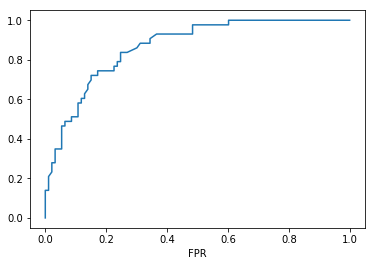

```python
import matplotlib.pyplot as plt
%matplotlib inline
ROC=model.stages[2].summary.roc
df=ROC.toPandas()

df.plot(x='FPR', y='TPR', legend=False)
```